# Sesión N° 2

Estadística para el análisis político 2

17 de septiembre de 2020

## Paquetes a utilizar

```r
library(jsonlite) #para extraer datos del API
library(stringr) #para limpieza de columnas (extracción de numeros, particiones)
library(readr)   #para extraer un único numero de la columna
library(htmltab) #para scraping
```

# PRIMERA PARTE: API + PREPROCESAMIENTO

Los API permiten construir pedidos de datos a través de una dirección web. Para que el trabajo de colección de datos sea exitoso, necesitamos revisar la documentación API de la página de interes.

## Ejercicio 1 - API Municipalidad de San Isidro

Dirección web: http://www.msi.gob.pe/portal/

El API de la Municipalidad de San Isidro indica que el pedido de información necesita dos elementos: 1. Un contraseña personal (API key) 2. Una solicitud básica (request)

llave=W1dJl8FYPOlhejAfYrg9Am7zbMEFYsRBZ0IgsZtC

La documentación API sugiere que para visualizar datos podemos usar:

```r
ordenesSI = fromJSON("http://api.datosabiertos.msi.gob.pe/api/v2/datastreams/ORDEN-DE-BIENE-SERVI-2020/data.json/?auth_key=W1dJl8FYPOlhejAfYrg9Am7zbMEFYsRBZ0IgsZtC")

ordenesSI <- ordenesSI[["result"]][["fArray"]]

#cambiando el formato
ordenesSI2 = fromJSON("http://api.datosabiertos.msi.gob.pe/api/v2/datastreams/ORDEN-DE-BIENE-SERVI-2020/data.pjson/?auth_key=W1dJl8FYPOlhejAfYrg9Am7zbMEFYsRBZ0IgsZtC")

ordenesSI2 <- ordenesSI2[["result"]]

#duplico el data frame para no alterar el original
data = ordenesSI2

names(data)
```

```
##  [1] "Numero-de-la-Orden"      "Nombre-del-Proveedor"
##  [3] "Mes-de-la-Orden"         "Numero-de-SIAF"
##  [5] "Tipo-de-Orden"           "Fecha-de-la-Orden"
##  [7] "Descripcion-de-la-Orden" "Monto-de-la-Orden"
##  [9] "Ano-de-la-Orden"         "Periodo-de-la-Orden"
## [11] "RUC-de-la-Entidad"       "timestamp"
## [13] "length"
```

Ahora queremos saber cuantas columnas o variables tiene mi data.frame

```r
ncol(data) #columnas
```

```
## [1] 13
```

Lo mismo con la cantidad de filas o casos que tiene la data

```r
nrow(data) #filas
```

```
## [1] 1000
```

Por último nos interesa hacer un histograma de los gastos en los que han incurrido la Municipalidad de San Isidro durante el 2020

```r
#Nos damos cuenta que hay que limpiar la base de datos
#primero eliminamos la última fila que está en blanco
data = data[-1000, ]
```

Si deseamos convertir la varaible a numerica nos daremos cuenta que se presentan problemas puesto que está sucia.

Nos damos cuenta que tiene "," que separa los miles.

Tenemos que usar métodos para limpiar la columna.

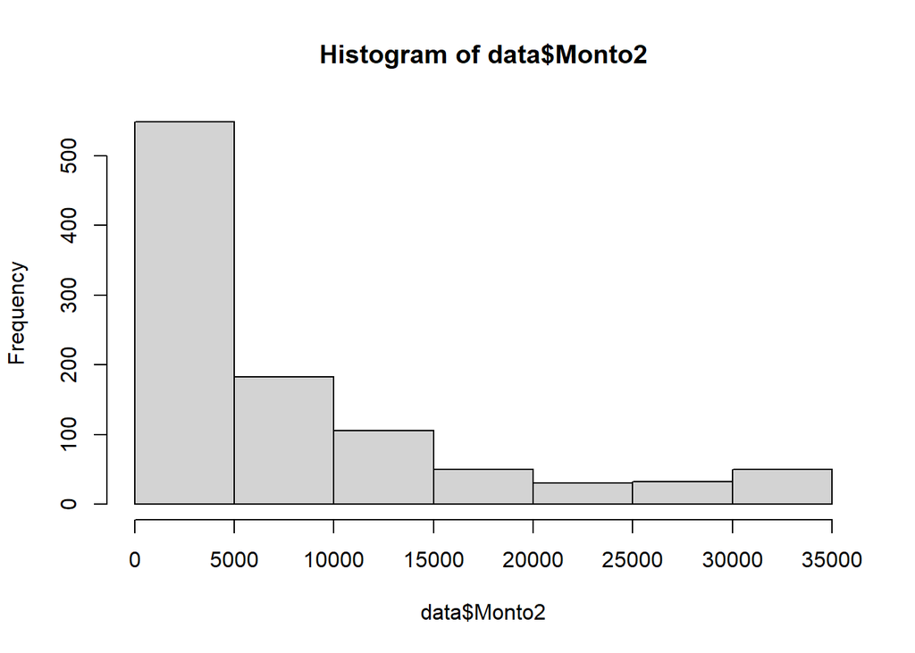

```r
data$Monto2 = parse_number(data$`Monto-de-la-Orden`) # Extrae los números.

#Otra opción
data$Monto3 = gsub(",", "", data$`Monto-de-la-Orden`) # Reemplaza
data$Monto3 = as.numeric(data$Monto3) # Una vez esté limpia, la convertimos en numérica

#Ya estamos más que listos!
hist(data$Monto2)
```

## Ejercicio 2 - API Candidatos USA

Vamos a ver el Federal Election Comision de Estados Unidos

Web: https://api.open.fec.gov/developers/

millave = V0REXgLBkKffVgEPId60k0FHHrgXanFDwpXfDQWm

```r
FEC = fromJSON("https://api.open.fec.gov/v1/candidates/totals/?api_key=V0REXgLBkKffVgEPId60k0FHHrgXanFDwpXfDQWm")

candidatos = FEC[["results"]]

candidatos$nombre = str_split(string = candidatos$name,
          pattern = ', ', simplify = T)[,2]

candidatos$apellido = str_split(string = candidatos$name,
          pattern = ', ', simplify = T)[,1]

table(candidatos$party_full)
```

```
##
##  DEMOCRATIC PARTY       GREEN PARTY LIBERTARIAN PARTY              NONE
##                12                 1                 1                 1
##  REPUBLICAN PARTY
##                 5
```

# SEGUNDA PARTE: WEB SCRAPING + PREPROCESAMIENTO

Bien ahora, trabajaremos con la [página de la CIA](https://www.cia.gov/library/publications/resources/the-world-factbook/docs/rankorderguide.html) en la cual figuran varias tablas de países con distintos indicadores.

## Ejercicio 3: PBI

Utilicemos la información de [este link](https://www.cia.gov/library/publications/resources/the-world-factbook/fields/211rank.html)

Bajamos la data:

```r
web1 = "https://www.cia.gov/library/publications/resources/the-world-factbook/fields/211rank.html"
path1 = '//*[@id="rankOrder"]'

data1 = htmltab(doc = web1, which =path1)
```

```
## No encoding supplied: defaulting to UTF-8.
```

Vemos que la variable de nuestro interés está "sucia" pues tiene el símbolo "$" y ",".

Entonces le decimos al programa que reemplace ambos caractéres por "" (nada):

```r
names(data1)
```

```
## [1] "Rank"                   "Country"                "GDP - per capita (PPP)"
## [4] "Date of Information"
```

```r
data1$var1 = data1$'GDP - per capita (PPP)'
data1[1,5]
```

```
## [1] "$139,100"
```

```r
data1$var1 = parse_number(data1$var1)
head(data1)
```

```
##   Rank       Country GDP - per capita (PPP) Date of Information   var1
## 2    1 Liechtenstein               $139,100           2009 est. 139100
## 3    2         Qatar               $124,100           2017 est. 124100
## 4    3         Macau               $122,000                2018 122000
## 5    4        Monaco               $115,700           2015 est. 115700
## 6    5    Luxembourg               $105,100           2017 est. 105100
## 7    6       Bermuda                $99,400           2016 est.  99400
```

## Ejercicio 4: Exportaciones

[Link](https://www.cia.gov/library/publications/resources/the-world-factbook/fields/239rank.html)

```r
web2 = "https://www.cia.gov/library/publications/resources/the-world-factbook/fields/239rank.html"
path2 = '//*[@id="rankOrder"]'

data2 = htmltab(doc = web2, which =path2)
```

```
## No encoding supplied: defaulting to UTF-8.
```

```r
head(data2)
```

```
##   Rank       Country            Exports Date of Information
## 2    1         China $2,490,000,000,000                2018
## 3    2 United States $1,553,000,000,000           2017 est.
## 4    3       Germany $1,434,000,000,000           2017 est.
## 5    4         Japan   $688,900,000,000           2017 est.
## 6    5  Korea, South   $577,400,000,000           2017 est.
## 7    6   Netherlands   $555,600,000,000           2017 est.
```

Vemos que la variable de nuestro interés está "sucia" pues tiene el símbolo "$" y ",".

Entonces le decimos al programa que reemplace ambos caractéres por "" (nada):

```r
names(data2)
```

```
## [1] "Rank"                "Country"             "Exports"
## [4] "Date of Information"
```

```r
data2[1,5] #Con esto podemos ver el primer elemento de ese vector para darle una revisión
```

[output not shown]

```r
data2$var1 = parse_number(data2$Exports)
head(data2$var1)
```

```
## [1] 2.490e+12 1.553e+12 1.434e+12 6.889e+11 5.774e+11 5.556e+11
```

Luego lo convertimos a numérico y cambiamos de escala (en millones)

```r
data2$var1 = data2$var1/1000000
names(data2)[names(data2)=='var1']='ExportacionesMillones'
```

## Ejercicio 5: Emisiones de dióxido de carbono

En el siguiente link tenemos una [tabla sobre emisiones de dióxido de carbono](https://www.cia.gov/library/publications/resources/the-world-factbook/fields/274.html)

Obtenemos la base de datos utilizando el *scrapping web*:

```r
library(htmltab)
web3 = "https://www.cia.gov/library/publications/resources/the-world-factbook/fields/274.html"
path3 = '//*[@id="fieldListing"]'
data3 = htmltab(doc = web3, which =path3)
```

```
## No encoding supplied: defaulting to UTF-8.
```

Ahora vemos rápidamente la base obtenida para ver si está "limpia o sucia":

```r
head(data3)
```

```
##               Country Carbon dioxide emissions from consumption of energy
## 2         Afghanistan                         9.067 million Mt(2017 est.)
## 3             Albania                           4.5 million Mt(2017 est.)
## 4             Algeria                         135.9 million Mt(2017 est.)
## 5      American Samoa                               361,100 Mt(2017 est.)
## 6              Angola                         20.95 million Mt(2017 est.)
## 7 Antigua and Barbuda                               740,300 Mt(2017 est.)
```

Vemos más de cerca el primer elemento del segundo vector (segunda columna):

```r
data3[1,2]
```

```
## [1] "9.067 million Mt(2017 est.)"
```

Identificamos el patrón: hay algunos números (también expresados con palabras) que luego son seguidos por Mt (año est.)

Creamos la var1 que será nuestra variables base. Eliminamos la anterior. Creamos la variable 2, la cual será la primera parte de esta variable, dividida por el término "Mt".

```r
names(data3)
```

```
## [1] "Country"
## [2] "Carbon dioxide emissions from consumption of energy"
```

```r
data3$var1 = data3$`Carbon dioxide emissions from consumption of energy`
data3$var2=str_split(string = data3$var1,
                         pattern = 'Mt',
                        simplify = T)[,1]
```

```r
head(data3)[,3]
```

```
## [1] "9.067 million Mt(2017 est.)" "4.5 million Mt(2017 est.)"
## [3] "135.9 million Mt(2017 est.)" "361,100 Mt(2017 est.)"
## [5] "20.95 million Mt(2017 est.)" "740,300 Mt(2017 est.)"
```

Una vez que hemos dividido la celda nos damos cuenta que algunas están en miles, otras en millones (con la palabra "million") y otras en billones (con la palabra "billion"). Esto es un problema

Por ello, debemos **reemplazar** estas palabras (million, billion) por números para poder convertir estas variables en **numéricas**.

Entonces, nuevamente dividimos esa variable (var2) y el caracter de separación será el " ".

Crearemos el vector "número" que será el número base y el "mult" que será el multiplicador.

```r
data3$numero=str_split(string = data3$var2,
                         pattern = ' ',
                         simplify = T)[,1]
data3$mult=str_split(string = data3$var2,
                         pattern = ' ',
                         simplify = T)[,2]
table(data3$mult)
```

```
##
##         billion million
##      46       7     163
```

Una vez que creamos dichos vectores los visualizamos.

```r
head(data3$numero)
```

```
## [1] "9.067"   "4.5"     "135.9"   "361,100" "20.95"   "740,300"
```

```r
head(data3$mult)
```

```
## [1] "million" "million" "million" ""        "million" ""
```

Ahora veamos la columna "mult" y comencemos a reemplazar.

La palabra "million" por 1000000:

```r
data3$mult = gsub('million',"1000000",data3$mult) # reemplaza la palabra million por el número correspondiente.
```

La palabra "billion" por 1000000000:

```r
data3$mult = gsub('billion',"1000000000",data3$mult) # reemplaza la palabra billion por el número correspondiente.
```

Los espacios vacíos por 1 (para que el resultado sea el mismo).

```r
data3$mult[data3$mult == ""] <- "1" # reemplaza los espacios vacíos por el número 1.
```

Ahora en el vector del número base hay que reemplazar las "," por "":

```r
data3$numero = parse_number(data3$numero) # extraemos el numero sin ","
```

Ahora volvemos el multiplicador en numéricos:

```r
data3$mult = as.numeric(data3$mult)
```

Finalmente calculamos una nueva variable que sea la multiplicación entre el número base y el multiplicador (1, millón o billón)

```r
data3$final = (data3$numero*data3$mult)
data3$final = (data3$final/1000000000)
```

Finalmente ya tenemos nuestra variable expresada en billones.

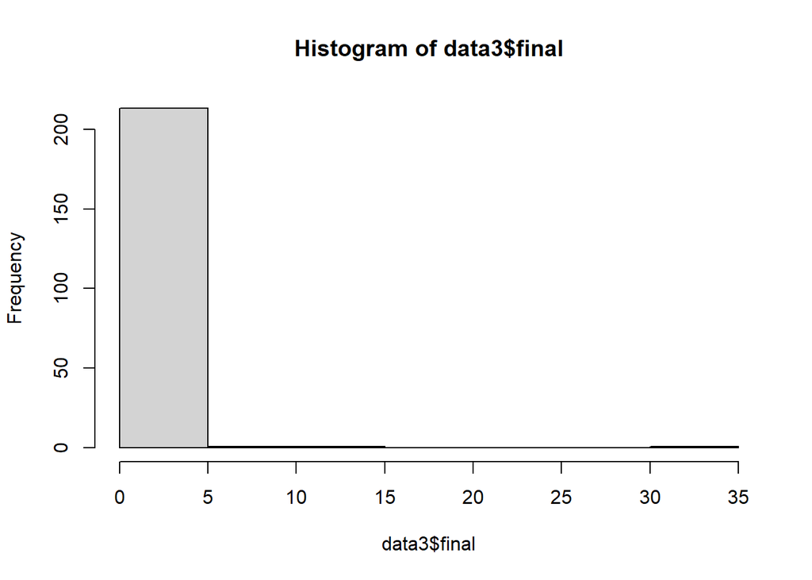

```r
hist(data3$final)
```